# HW1

Ali Ozan Memetoğlu

11/20/2020

# Data Visualization with Google Trends

## 1) Daily Total Number of Covid Cases in Turkey

**Setup Stage:**

```r
library('data.table', quietly = TRUE)
library('ggplot2', quietly = TRUE)
library('dplyr')
library('lubridate', quietly = TRUE)

setwd('/Users/aliozan.memetoglu/Documents/GitHub/fall20-aliozanmemeto/files')
covid_data <- fread("owid-covid-data.csv",
              select = c("location", "total_cases", "date"))[location == ('Turkey')]

# Data is from https://github.com/owid/covid-19-data/tree/master/public/data
```

Because the location column is not needed anymore, it is removed. A function ‘fancy scientific’ is defined for visual purposes in graph breaks.

```r
covid_data[,location:=NULL]

fancy_scientific <- function(l) {
  # turn in to character string in scientific notation
  l <- format(l, scientific = TRUE)
  # quote the part before the exponent to keep all the digits
  l <- gsub("^(.*)e", "'\\1'e", l)
  # turn the 'e+' into plotmath format
  l <- gsub("e", "%*%10^", l)
  # return this as an expression
  parse(text=l)
}
```

First a quick and dirty line graph which indicates there is an increasing trend

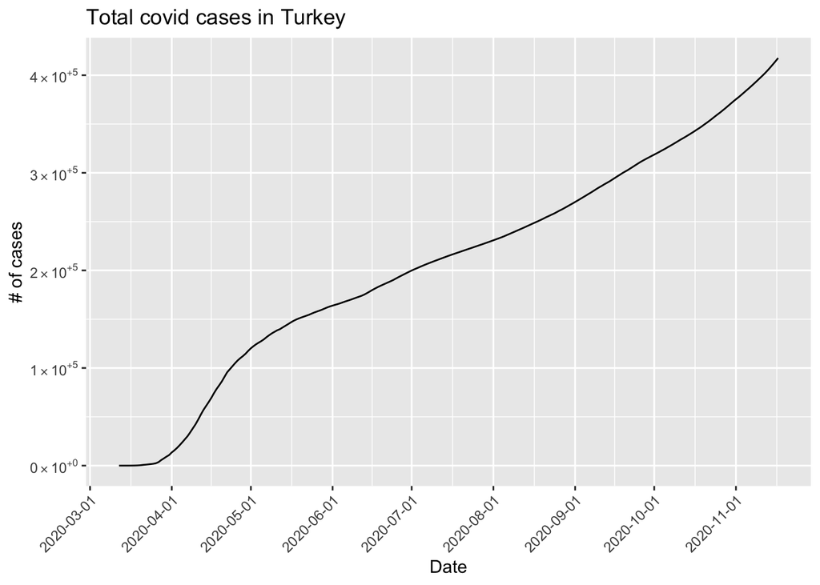

```r
ggplot(covid_data, aes(x=date, y=total_cases)) + geom_line() +
  labs(title = "Total covid cases in Turkey",
       x = "Date",
       y = "# of cases") +
  scale_x_date(date_breaks = "1 month") +
  scale_y_continuous(labels=fancy_scientific) + theme(axis.text.x = element_text(angle = 45, hjust = 1))
```

In the next step, the data in March and November is removed initially. Then monthly histograms are provided to check if the shape of histogram is changing significantly over the months between 4th to 10th. Unfortunately there are not any consistent shapes we see every month.

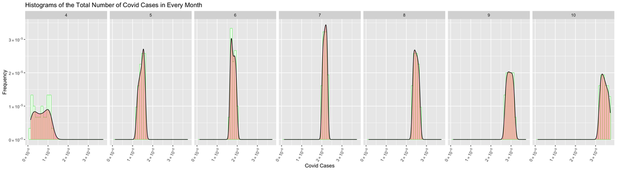

```r
monthly_plot = covid_data[month(date)!=3 & month(date)!= 11]
ggplot(monthly_plot, aes(x=total_cases)) +
  geom_histogram(aes(y=..density..), colour="lightgreen",fill='white', binwidth = 10000)+
  geom_density(alpha=.4, fill="#FF6666") +
  labs(title = "Histograms of the Total Number of Covid Cases in Every Month",
       x = "Covid Cases",
       y = "Frequency") + scale_x_continuous(labels=fancy_scientific)+ scale_y_continuous(labels=fancy_scientific)   +

  theme(axis.text.x = element_text(angle = 60, hjust = 1)) +
  facet_grid(~month(date))
```

As for box-plots with respect to months, which are pretty similar to the line graph above, we can make an inference about the daily means and variances of months.

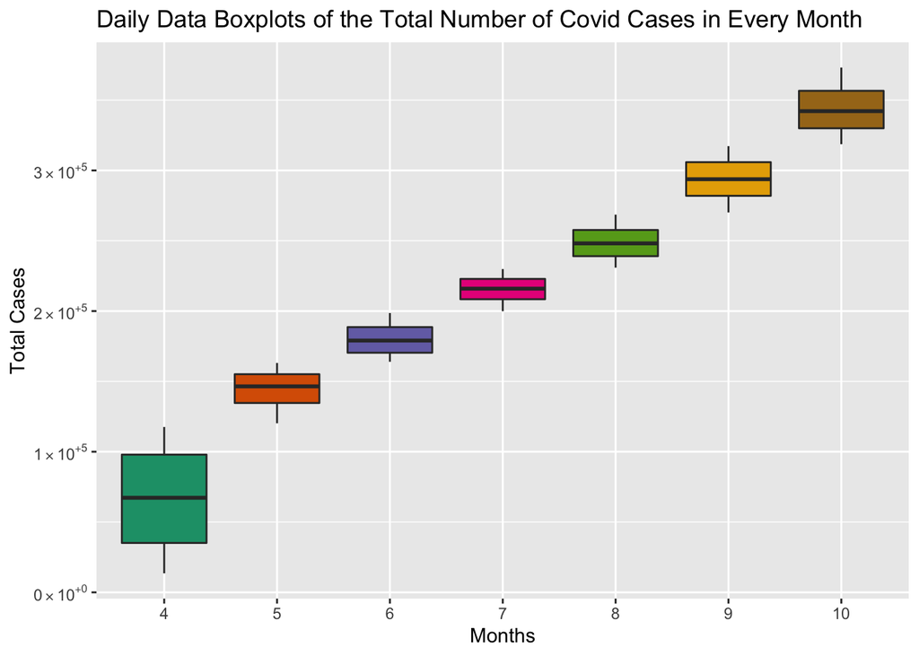

```r
ggplot(monthly_plot, aes(x= as.factor(month(date)), y = total_cases, fill=as.factor(month(date)))) +
  geom_boxplot(aes(group = month(date))) +
  labs(title = "Daily Data Boxplots of the Total Number of Covid Cases in Every Month",
       x = "Months",
       y = "Total Cases") +
  theme(legend.position="none") + scale_y_continuous(labels=fancy_scientific) +
  scale_fill_brewer(palette="Dark2")
```

Google trend data for the search “korona belirtisi” is read and filtered for those months accordingly.

```r
korona_belirtisi <- fread("multiTimeline.csv", select = c("Week", "korona belirtisi: (Turkey)"))
setnames(korona_belirtisi, "korona belirtisi: (Turkey)", "interest")
setnames(korona_belirtisi, "Week", "week")

print(min(as.Date(covid_data$date)))
```

```
## [1] "2020-03-12"
```

```r
print(max(as.Date(covid_data$date)))
```

```
## [1] "2020-11-17"
```

```r
korona_belirtisi <- korona_belirtisi[week >= ymd('20200401') & week < ymd('20201101')]
```

The range of boxplot is different in this case, probably due to the fact that this data contains the interest for “korona belirtisi” on a **weekly** basis.

[figure not shown]

```r
ggplot(korona_belirtisi, aes(x= as.factor(month(week)), y = interest, fill=as.factor(month(week)))) +
  geom_boxplot(aes(group = month(week))) +
  labs(title = "Weekly Data Boxplots of the Interest over Search Term - korona belirtisi in Every Month",
       x = "Months",
       y = "the Interest over Search Term - korona belirtisi") +
  theme(legend.position="none")  +
  scale_fill_brewer(palette="Dark2")
```

To sum up, whilst the covid data follows an increasing fashion, search term - korona belirtisi seems more like a stationary data with a visual inspection.